# Predicting outcome of Professional Tennis Matches with KNN Classifier

## Introduction

The ATP Tour is a worldwide top-tier tennis tour for men organized by the Association of Tennis Professionals. The ATP Tour comprises ATP Masters 1000, ATP 500, and ATP 250, and the higher the numbers behind, the higher rank of the tournaments. We’ve done research on the probability of winning, and it is mentioned that playing the first serve successfully helps to win the game. Hence, our project will use the ATP tour data from 2017 to 2019 to analyze whether the players’ age, height and performance during the game is related to the result of the game. We would like to predict whether or not a player can win the game based on their height, age and performance during the game. We will construct several models using different predictors, and include the best two predictors into our final model. The question we want to answer is if we can build a classifier to accurately predict the outcome of a tennis match based on height, age, and other tennis statistics. We will construct several models using different predictors, and include the best predictors (up to three) for our final model. The data we will be basing our analysis on is from https://github.com/JeffSackmann/tennis_atp, specifically using the data from 2017-2019. We will be mutating this data to include only a subset of columns to use as predictors (listed in the exploratory data analysis section), along with the outcome of the match.

## Exploratory Data Analysis

```r
# Import Libaries
library(tidyverse)
library(tidymodels)
library(repr)
library(rvest)
library(stringr)
options(repr.matrix.max.rows = 6)
```

```r
# Load and mutate data
tennis_data_2019<-read.csv('https://raw.githubusercontent.com/JeffSackmann/tennis_atp/master/atp_matches_2019.csv')
tennis_data_2018<-read.csv('https://raw.githubusercontent.com/JeffSackmann/tennis_atp/master/atp_matches_2018.csv')
tennis_data_2017<-read.csv('https://raw.githubusercontent.com/JeffSackmann/tennis_atp/master/atp_matches_2017.csv')
tennis_data <- bind_rows(tennis_data_2019, tennis_data_2018, tennis_data_2017)
winner_data <- select(tennis_data, c(winner_name,
                      winner_age,
                      winner_ht,
                      w_ace,
                      w_df,
                      w_svpt,
                      w_1stIn,
                      w_1stWon,
                      w_SvGms,
                      w_bpSaved,
                      w_bpFaced)) %>%
                rename(name=winner_name,
                      age=winner_age,
                      height=winner_ht,
                      aces=w_ace,
                      double_faults=w_df,
                      serve_points=w_svpt,
                      first_serves_made=w_1stIn,
                      first_serve_points=w_1stWon,
                      serve_games=w_SvGms,
                      break_points_saved=w_bpSaved,
                      break_points_faced=w_bpFaced) %>%
                add_column(match_result='win')
loser_data <- select(tennis_data, c(loser_name,
                      loser_age,
                      loser_ht,
                      l_ace,
                      l_df,
                      l_svpt,
                      l_1stIn,
                      l_1stWon,
                      l_SvGms,
                      l_bpSaved,
                      l_bpFaced)) %>%
                rename(name=loser_name,
                      age=loser_age,
                      height=loser_ht,
                      aces=l_ace,
                      double_faults=l_df,
                      serve_points=l_svpt,
                      first_serves_made=l_1stIn,
                      first_serve_points=l_1stWon,
                      serve_games=l_SvGms,
                      break_points_saved=l_bpSaved,
                      break_points_faced=l_bpFaced) %>%
                add_column(match_result='lose')
tennis_data_mod <- bind_rows(winner_data, loser_data)
```

```r
# Split Data into Train and Test Sets

tennis_split <- initial_split(tennis_data_mod, prop=0.75, strata=match_result)
tennis_train <- training(tennis_split)
tennis_test <- testing(tennis_split)
```

```r
# mean for each predictor
predictors_mean<- map_dfr(tennis_train[,2:10], mean, na.rm=TRUE)
predictors_mean

# distribution of match results in training set
match_result_dist <- tibble(num_of_wins=nrow(filter(tennis_train, match_result=='win')), num_of_loses=nrow(filter(tennis_train, match_result=='lose')))
match_result_dist

# count of NA's in each predictor column
count_of_nas <- map_dfr(tennis_train[,2:10], ~sum(is.na(.)))
count_of_nas
```

A tibble: 1 × 9

| age <dbl> | height <dbl> | aces <dbl> | double_faults <dbl> | serve_points <dbl> | first_serves_made <dbl> | first_serve_points <dbl> | serve_games <dbl> | break_points_saved <dbl> |
| --- | --- | --- | --- | --- | --- | --- | --- | --- |
| 27.70797 | 187.2478 | 6.581229 | 3.135541 | 81.58361 | 50.05741 | 35.98475 | 12.7872 | 4.103541 |

A tibble: 1 × 2

| num_of_wins <int> | num_of_loses <int> |
| --- | --- |
| 6417 | 6417 |

A tibble: 1 × 9

| age <int> | height <int> | aces <int> | double_faults <int> | serve_points <int> | first_serves_made <int> | first_serve_points <int> | serve_games <int> | break_points_saved <int> |
| --- | --- | --- | --- | --- | --- | --- | --- | --- |
| 1 | 1109 | 240 | 240 | 240 | 240 | 240 | 240 | 240 |

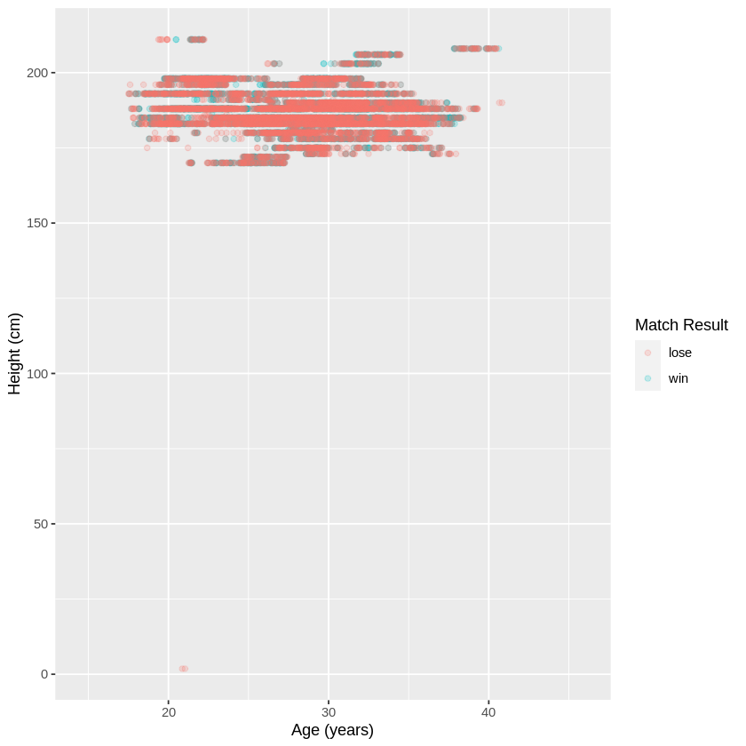

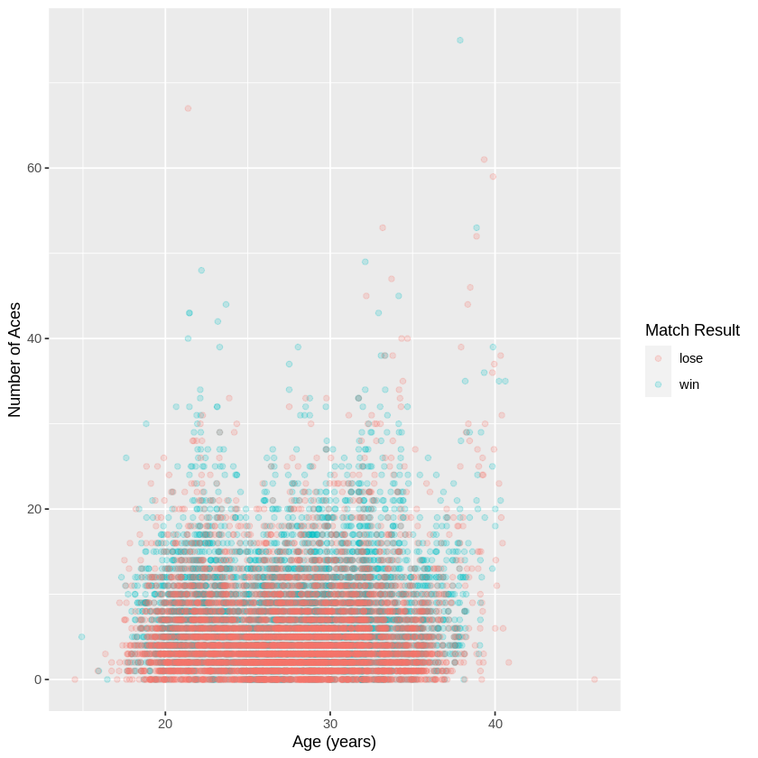

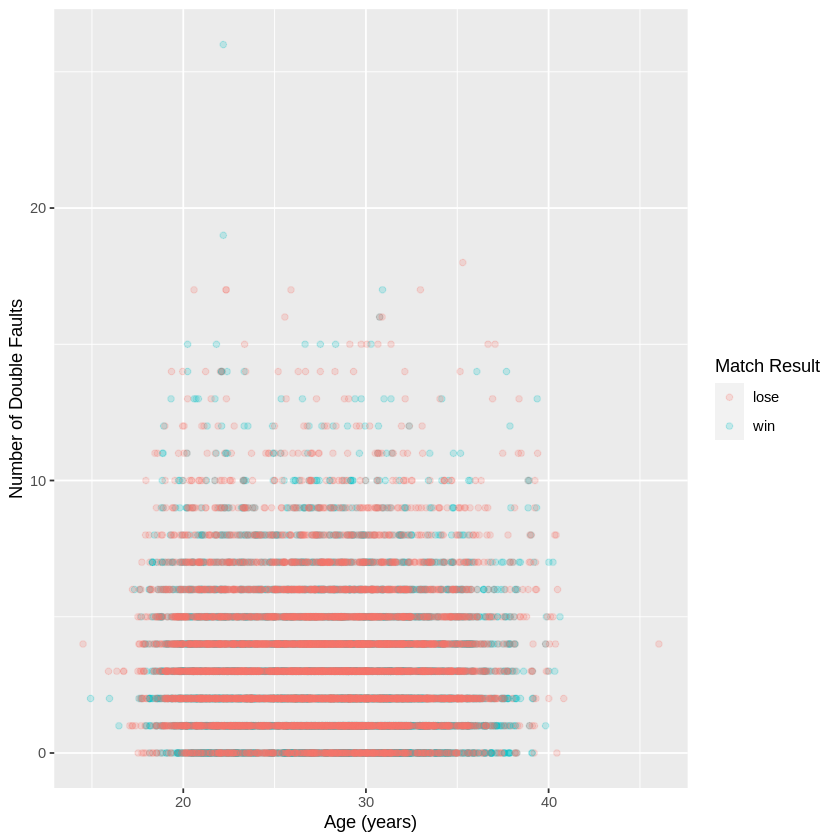

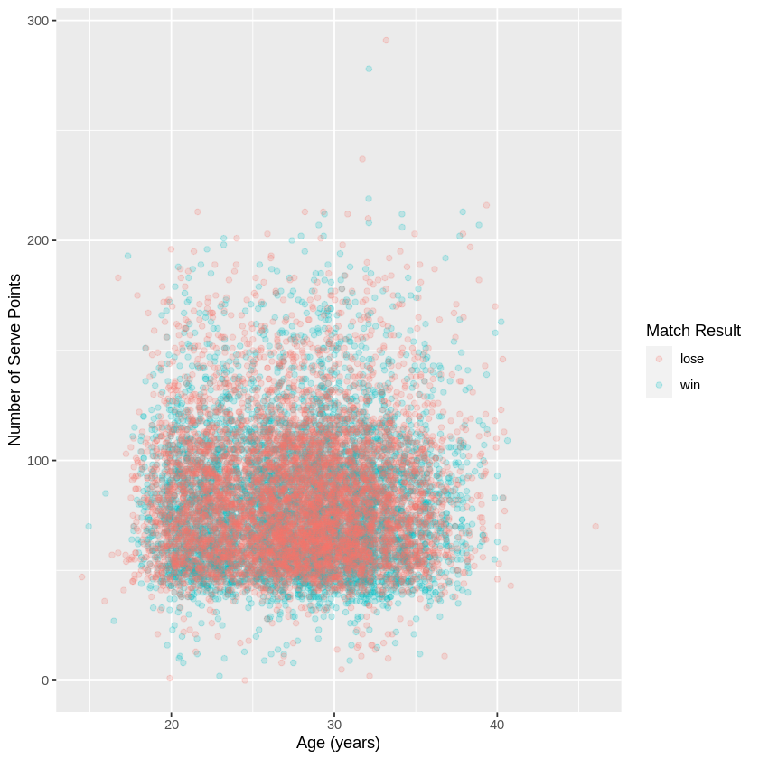

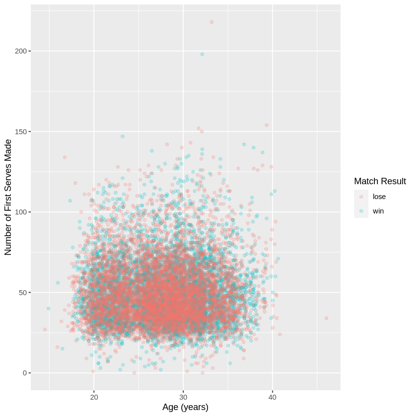

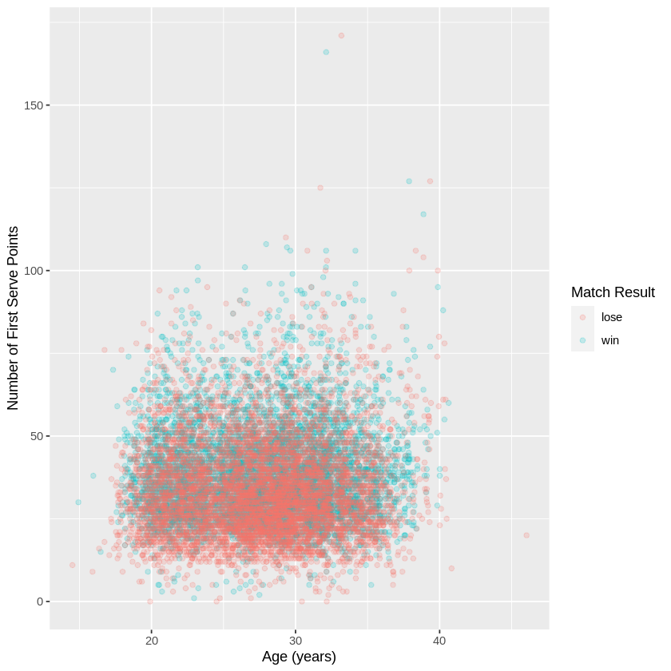

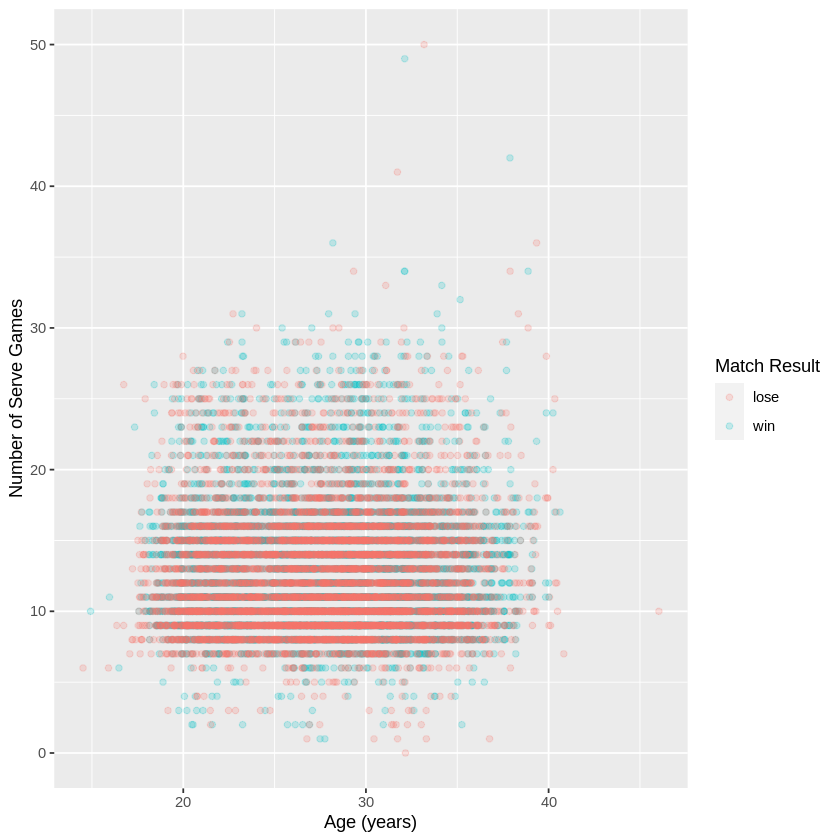

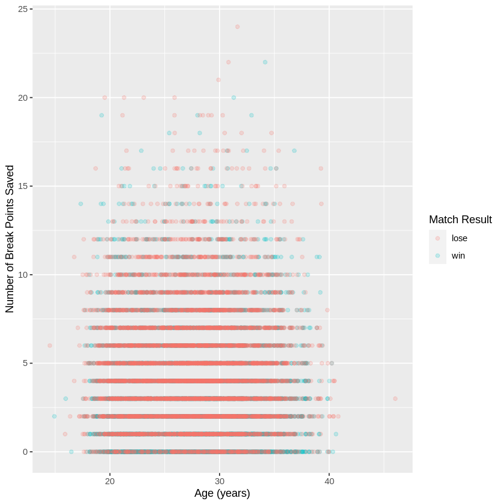

```r
tennis_train_plot_1 <- tennis_train %>%
                            ggplot(aes(x=age, y=height,color=match_result)) +
                            geom_point(alpha=0.2) +
                            labs(x="Age (years)", y="Height (cm)", color='Match Result')

tennis_train_plot_2 <- tennis_train %>%
                            ggplot(aes(x=age, y=aces, color=match_result)) +
                            geom_point(alpha=0.2) +
                            labs(x="Age (years)", y="Number of Aces", color='Match Result')

tennis_train_plot_3 <- tennis_train %>%
                            ggplot(aes(x=age, y=double_faults, color=match_result)) +
                            geom_point(alpha=0.2) +
                            labs(x="Age (years)", y="Number of Double Faults", color='Match Result')

tennis_train_plot_4 <- tennis_train %>%
                            ggplot(aes(x=age, y=serve_points, color=match_result)) +
                            geom_point(alpha=0.2) +
                            labs(x="Age (years)", y="Number of Serve Points", color='Match Result')

tennis_train_plot_5 <- tennis_train %>%
                            ggplot(aes(x=age, y=first_serves_made, color=match_result)) +
                            geom_point(alpha=0.2) +
                            labs(x="Age (years)", y="Number of First Serves Made", color='Match Result')

tennis_train_plot_6 <- tennis_train %>%
                            ggplot(aes(x=age, y=first_serve_points, color=match_result)) +
                            geom_point(alpha=0.2) +
                            labs(x="Age (years)", y="Number of First Serve Points", color='Match Result')

tennis_train_plot_7 <- tennis_train %>%
                            ggplot(aes(x=age, y=serve_games, color=match_result)) +
                            geom_point(alpha=0.2) +
                            labs(x="Age (years)", y="Number of Serve Games", color='Match Result')

tennis_train_plot_8 <- tennis_train %>%
                            ggplot(aes(x=age, y=break_points_saved, color=match_result)) +
                            geom_point(alpha=0.2) +
                            labs(x="Age (years)", y="Number of Break Points Saved", color='Match Result')


tennis_train_plot_1
tennis_train_plot_2
tennis_train_plot_3
tennis_train_plot_4
tennis_train_plot_5
tennis_train_plot_6
tennis_train_plot_7
tennis_train_plot_8
```